# K Nearest Neighbors Classifier

MDS. René Rosado González

## Consumo de agua en la CDMX

Para este análisis intentaremos predecir el índice de desarrollo por colonia en función del consumo de agua y su ubicación geográfica.

## Librerías

```r
# Instala - carga tidyverse
if(require(tidyverse) == FALSE){
  install.packages('tidyverse')
  library(tidyverse)
}else{
  library(tidyverse)
}
# Instala - carga tidymodels
if(require(tidymodels) == FALSE){
  install.packages('tidymodels')
  library(tidymodels)
}else{
  library(tidymodels)
}
# Instala - kknn
if(require(kknn) == FALSE){
  install.packages('kknn')
}
```

## Solución paso a paso

1. Carga el conjunto de datos en un objeto llamado `consumo_agua` (0.5 pts)

```r
# Este conjutno de datos está disponible en el portal de Datos Abierto de la CDMX
# 1. Leer datos
consumo_agua = read_csv("https://datos.cdmx.gob.mx/dataset/eb38823c-488a-49e8-a2cf-62e628fa246f/resource/2263bf74-c0ed-4e7c-bb9c-73f0624ac1a9/download/consumo_agua_historico_2019.csv")
```

2. Filtra el conjunto de datos de tal forma que solo conserves el primer bimestre (0.5 pts)
3. Filtra las observaciones de tal forma que no tengas NAs en las columnas `alcaldia` y `colonia` (0.5 pts)
4. Transforma la variable `indice_des` a un factor con el siguiente orden `POPULAR`, `BAJO`, `MEDIO`, `ALTO` (0.5 pts)

```r
primer_bimestre = consumo_agua %>%
  filter(
    # 2. Filtrar primer bimestre
    bimestre == 1,
    # 3. Filtrar NAs
    !is.na(alcaldia),
    !is.na(colonia)
    ) %>%
  mutate(
    # Transformar indice_des a factor
    indice_des = factor(indice_des, levels = c('POPULAR','BAJO','MEDIO','ALTO'))
  )
```

5. Utilizando `ggplot` genera un gráfico de cajas que compare `indice_des` y `consumo_total` para cada `alcaldia` (TIP: si el gráfico no resulta lo suficientemente informativo, intenta transformar `consumo_total` usando logaritmos y/o raíces) (1 pts)

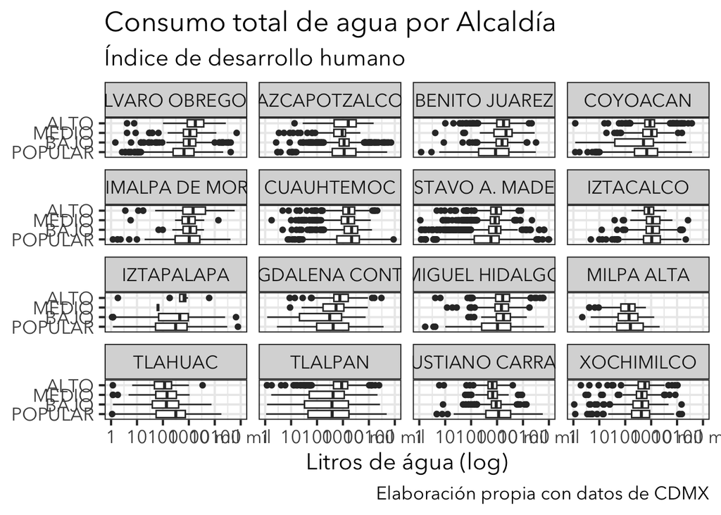

```r
# Crear un lienzo y fijar las variables por eje
ggplot(primer_bimestre, aes(x = consumo_total, y = indice_des)) +
  # Agregar un boxplot
  geom_boxplot() +
  # Modificar el eje x
  scale_x_continuous(
    limits = c(1,NA),
    trans='log10',
    breaks = c(1,10,100,1000,10000,100000),
    labels = c('1','10','100','1000','10 mil','100 mil')
    ) +
  # Separar por alcaldía en 4 columnas
  facet_wrap(~alcaldia, ncol = 4) +
  # Agregar etiquetas
  labs(
    title = 'Consumo total de agua por Alcaldía',
    subtitle = 'Índice de desarrollo humano',
    caption = 'Elaboración propia con datos de CDMX',
    x = 'Litros de água (log)'
  ) +
  # Modificar tema
  theme_bw(base_size = 16, base_family = 'Avenir Next') +
  theme(
    # Quitar título del eje y
    axis.title.y = element_blank()
  )
```

```r
modelo_knn = nearest_neighbor() %>%
  # Fijar motor
  set_engine("kknn") %>%
  # Fijar modo clasificación
  set_mode('classification') %>%
  # Fijar hyperparámetros
  set_args(
    neighbors = tune(),
    dist_power = tune(),
    weight_func = tune()
    )

# Separar en prueba y entrenaiento
set.seed(123)
split = initial_split(
  # Conjunto de datos
  data = primer_bimestre,
  # Proporciones
  prop = 0.80,
  # Variable of interest
  strata = indice_des
)

# Obtener conjunto de prueba y entrenamiento
train = training(split)
test = testing(split)

# Pliegues de validación cruzada
set.seed(123)
folds = vfold_cv(train, v = 3)

# Crear una receta
recipe = recipe(
  # Formula
  formula = indice_des ~ latitud + longitud + consumo_total,
  # Datos de entrenamiento
  data = train
)

# Fjulo de trabajo
knn_workflow = workflow() %>%
  # Agregar la receta
  add_recipe(recipe) %>%
  # Agregar el modelo
  add_model(modelo_knn)

# Extraer parámetros
knn_parameters = knn_workflow %>%
  extract_parameter_set_dials()

# Paralelizar nuestro trabajo
cluster = parallel::makeCluster(parallel::detectCores())
doParallel::registerDoParallel(cluster)

# Crear una malla de calibración
set.seed(123)
knn_tuning = tune_grid(
  # Trabajamos con nuestro flujo de trabajo
  object = knn_workflow,
  # Agregamos nuestros pliegues
  resamples = folds,
  # Agregamos nuestros parámetros
  param_info = knn_parameters,
  # Fijamos nuestras métricas
  metrics = metric_set(yardstick::accuracy),
  # Control de acciones
  control = control_grid(parallel_over = "everything" ),
  # Tamaño de la búsqueda
  grid = 100
  )

# Cerrar el cluster
parallel::stopCluster(cluster)

# Recolectar metricas de calibración
tuning_metrics = knn_tuning %>%
  collect_metrics() %>%
  # Ordenar de menor a mayor
  arrange(mean)

# Seleccionar mejor modelo
best_knn = knn_tuning %>%
  select_best(metric = "accuracy")

# Finalizar el flujo de trabajo
final_knn = knn_workflow %>%
  finalize_workflow(best_knn)

# Hacer el ajuste final
results_knn = final_knn %>%
  last_fit(
    split = split,
    metrics = metric_set(yardstick::accuracy)
    )

# Extraer métricas de prueba
metrics_knn = results_knn %>%
  collect_metrics()

print(metrics_knn)
```

```
## # A tibble: 1 × 4
##   .metric  .estimator .estimate .config
##   <chr>    <chr>          <dbl> <chr>
## 1 accuracy multiclass     0.628 Preprocessor1_Model1
```

7. Compara los valores predichos con los valores observados del conjunto original en un gráfico. (1 pts)

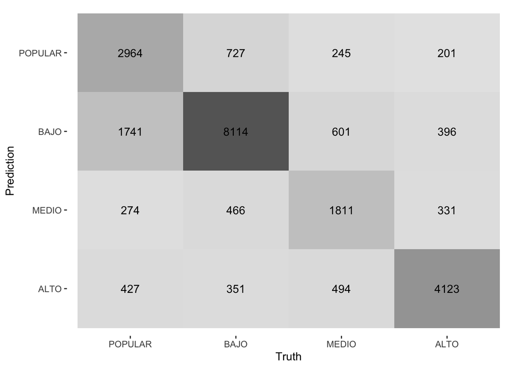

```r
# Extraer el modelo entrenado
knn_trained = results_knn %>%
  extract_fit_parsnip()

# Agregar predicciones
predictions_tb = augment(knn_trained, primer_bimestre)

# Matriz de confusión
predictions_tb %>%
  conf_mat(truth = indice_des, estimate = .pred_class) %>%
  autoplot(type = 'heatmap')
```

8. Genera los gráficos que consideres convenientes para explicar el efecto de `consumo_total` en las predicciones (2 pts)

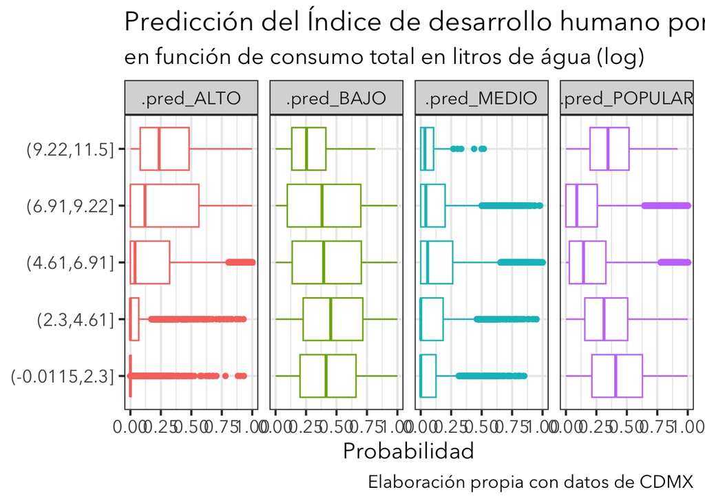

```r
# Gráfico
predictions_tb %>%
  # Columnas de interés
  select(.pred_POPULAR:.pred_ALTO, consumo_total) %>%
  # Cambiar formato
  gather(prediccion, probabilidad, - consumo_total) %>%
  # Calcular 100 bins
  mutate(consumo_total = cut(log(consumo_total+1), breaks = 5)) %>%
  ggplot(aes(y = consumo_total, x = probabilidad, col = prediccion)) +
  # Agregar puntos
  geom_boxplot(show.legend = FALSE) +
  # Separar por alcaldía en 4 columnas
  facet_wrap(~prediccion, ncol = 4) +
  # Agregar etiquetas
  labs(
    title = 'Predicción del Índice de desarrollo humano por colonia',
    subtitle = 'en función de consumo total en litros de água (log)',
    caption = 'Elaboración propia con datos de CDMX',
    x = 'Probabilidad'
  ) +
  # Modificar tema
  theme_bw(base_size = 16, base_family = 'Avenir Next') +
  theme(
    # Quitar título del eje y
    axis.title.y = element_blank()
  )
```

9. Con el modelo entrenado, realiza predicciones para el segundo bimestre y compara los valores predichos con los valores observados del conjunto original en un gráfico. (0.5 pts)

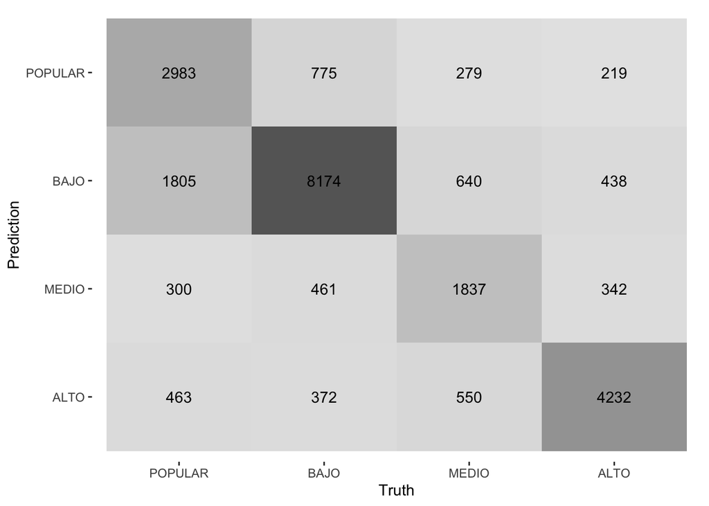

```r
# Agregar predicciones
predictions_tb = consumo_agua %>%
  filter(
    # 2. Filtrar primer bimestre
    bimestre == 2,
    # 3. Filtrar NAs
    !is.na(alcaldia),
    !is.na(colonia)
    ) %>%
  mutate(
    # Transformar indice_des a factor
    indice_des = factor(indice_des, levels = c('POPULAR','BAJO','MEDIO','ALTO'))
    ) %>%
  augment(x = knn_trained)

# Matriz de confusión
predictions_tb %>%
  conf_mat(truth = indice_des, estimate = .pred_class) %>%
  autoplot(type = 'heatmap')
```

10. Con el modelo entrenado, realiza predicciones para el tercer bimestre y compara los valores predichos con los valores observados del conjunto original en un gráfico. (0.5 pts)

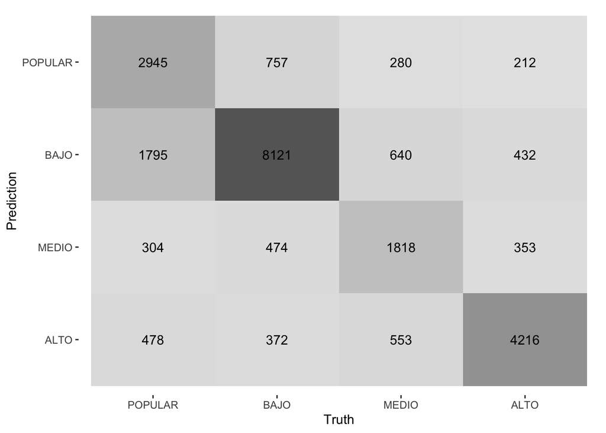

```r
# Agregar predicciones
predictions_tb = consumo_agua %>%
  filter(
    # 2. Filtrar primer bimestre
    bimestre == 3,
    # 3. Filtrar NAs
    !is.na(alcaldia),
    !is.na(colonia)
    ) %>%
  mutate(
    # Transformar indice_des a factor
    indice_des = factor(indice_des, levels = c('POPULAR','BAJO','MEDIO','ALTO'))
    ) %>%
  augment(x = knn_trained)

# Matriz de confusión
predictions_tb %>%
  conf_mat(truth = indice_des, estimate = .pred_class) %>%
  autoplot(type = 'heatmap')
```